# point_group

生井沢祥吾

2024-02-12

### データの読み込み

```r
library(readr)
point_abcd <- read_csv("../data/point_abcd.csv")
point_a <- read_csv("../data/point_A.csv")
point_b <- read_csv("../data/point_B.csv")
point_c <- read_csv("../data/point_C.csv")
point_d <- read_csv("../data/point_D.csv")
#View(point_abcd)
```

## 分析に必要なライブラリの読み込み

```r
library(ggplotgui)#ggplot_shiny(exdataset)をコンソールに打ち込んで実行する
library(forcats)
library(GGally)
library(dplyr)
library(ggeffects)
library(tidyverse)
library(sjPlot)
```

# **仮説１：女性の方が男性よりポイントへの意識が強い。**

## 対立仮説(主張したいこと)

#### 女性の方が男性よりポイントへの意識が強い。

## 帰無仮説

#### 女性の方が男性よりポイントへの意識が強いというわけではない。

## 分析方法

#### 性別`Sex`を説明変数,消費者ポイント層`PointTypes`を応答変数として**ダミー回帰分析**を行いました。

- データ解析論Ⅰ第12講を参考に分析

## 欠損値の削除

```r
point_abcd_1 <- subset(point_abcd, Sex!=9)
```

## グラフの作成

```
## No summary function supplied, defaulting to `mean_se()`
```

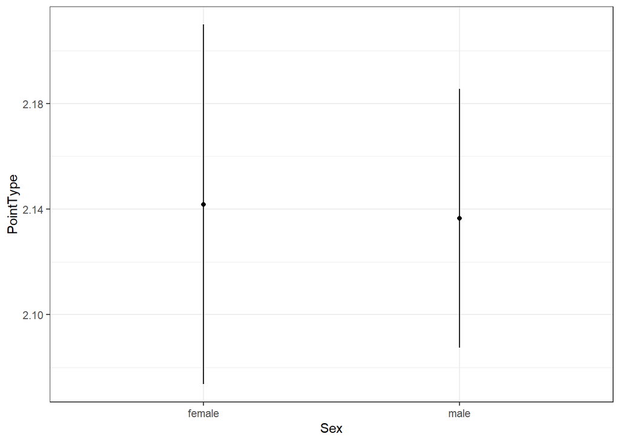

```r
# The code below will generate the graph:
graph <- ggplot(point_abcd_1, aes(x = Sex, y = PointType)) +
  geom_point(stat = 'summary', fun.y = 'mean') +
  geom_errorbar(stat = 'summary', fun.data = 'mean_se',
                width=0, fun.args = list(mult = 1.96)) +
  theme_bw()
graph
```

## 分析結果の出力(ダミー回帰分析)

```r
marhap_model <- lm(PointType ~ Sex, data = point_abcd_1)# lm(応答変数~説明変数, data = 対象のデータ)
summary(marhap_model)
```

```
##
## Call:
## lm(formula = PointType ~ Sex, data = point_abcd_1)
##
## Residuals:
##     Min      1Q  Median      3Q     Max
## -1.1418 -0.1418 -0.1365  0.1122  0.8635
##
## Coefficients:
##              Estimate Std. Error t value Pr(>|t|)
## (Intercept)  2.141791   0.035801  59.825   <2e-16 ***
## Sexmale     -0.005266   0.043482  -0.121    0.904
## ---
## Signif. codes:  0 '***' 0.001 '**' 0.01 '*' 0.05 '.' 0.1 ' ' 1
##
## Residual standard error: 0.5861 on 830 degrees of freedom
## Multiple R-squared:  1.767e-05,  Adjusted R-squared:  -0.001187
## F-statistic: 0.01467 on 1 and 830 DF,  p-value: 0.9036
```

### 分析結果の表

```r
library(sjPlot)
tab_model(marhap_model)
```

|  | PointType |  |  |
| --- | --- | --- | --- |
| Predictors | Estimates | CI | p |
| (Intercept) | 2.14 | 2.07 – 2.21 | **<0.001** |
| Sex [male] | -0.01 | -0.09 – 0.08 | 0.904 |
| Observations | 832 |  |  |
| R<sup>2</sup> / R<sup>2</sup> adjusted | 0.000 / -0.001 |  |  |

## 分析結果

# **仮説２：居住地域によってポイント感度が異なる。（関東、中部、近畿、その他）**

## 対立仮説(主張したいこと)

#### 居住地域によってポイント感度が異なる。

## 帰無仮説

#### 居住地域によってポイント感度が異なるというわけではない。

## 分析方法

#### 居住地域`Region`を説明変数,消費者ポイント層`PointTypes`を応答変数として**ダミー回帰分析**を行いました。

- データ解析論Ⅱ第２講を参考に分析

## 欠損値の削除

```r
point_abcd_1 <- subset(point_abcd, Region!=9)
```

## グラフの作成

```
## No summary function supplied, defaulting to `mean_se()`
```

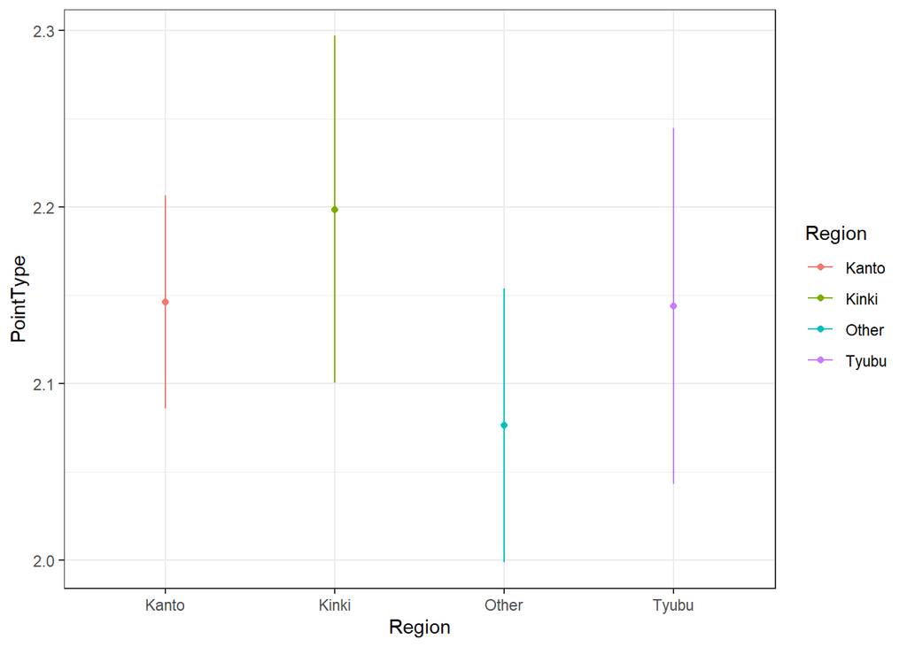

```r
graph <- ggplot(point_abcd_1, aes(x = Region, y = PointType, colour = Region)) +
  geom_point(stat = 'summary', fun.y = 'mean') +
  geom_errorbar(stat = 'summary', fun.data = 'mean_se',
                width=0, fun.args = list(mult = 1.96)) +
  theme_bw()
graph
```

## 分析結果の出力(ダミー回帰分析)

```r
pointreg_model <- lm(PointType ~ Region, data = point_abcd_1)# lm(応答変数~説明変数, data = 対象のデータ)
pointreg_model
```

```
##
## Call:
## lm(formula = PointType ~ Region, data = point_abcd_1)
##
## Coefficients:
## (Intercept)  RegionKinki  RegionOther  RegionTyubu
##    2.146269     0.052361    -0.070078    -0.002433
```

```r
summary(pointreg_model)
```

```
##
## Call:
## lm(formula = PointType ~ Region, data = point_abcd_1)
##
## Residuals:
##      Min       1Q   Median       3Q      Max
## -1.19863 -0.14627 -0.14384 -0.07619  0.92381
##
## Coefficients:
##              Estimate Std. Error t value Pr(>|t|)
## (Intercept)  2.146269   0.031892  67.297   <2e-16 ***
## RegionKinki  0.052361   0.057887   0.905    0.366
## RegionOther -0.070078   0.051378  -1.364    0.173
## RegionTyubu -0.002433   0.057887  -0.042    0.966
## ---
## Signif. codes:  0 '***' 0.001 '**' 0.01 '*' 0.05 '.' 0.1 ' ' 1
##
## Residual standard error: 0.5837 on 833 degrees of freedom
## Multiple R-squared:  0.004792,   Adjusted R-squared:  0.001207
## F-statistic: 1.337 on 3 and 833 DF,  p-value: 0.2611
```

### 分析結果の表

```r
library(sjPlot)
tab_model(pointreg_model)
```

|  | PointType |  |  |
| --- | --- | --- | --- |
| Predictors | Estimates | CI | p |
| (Intercept) | 2.15 | 2.08 – 2.21 | **<0.001** |
| Region [Kinki] | 0.05 | -0.06 – 0.17 | 0.366 |
| Region [Other] | -0.07 | -0.17 – 0.03 | 0.173 |
| Region [Tyubu] | -0.00 | -0.12 – 0.11 | 0.966 |
| Observations | 837 |  |  |
| R<sup>2</sup> / R<sup>2</sup> adjusted | 0.005 / 0.001 |  |  |

```r
anova(pointreg_model)
```

```
## Analysis of Variance Table
##
## Response: PointType
##            Df  Sum Sq Mean Sq F value Pr(>F)
## Region      3   1.367 0.45552  1.3369 0.2611
## Residuals 833 283.833 0.34074
```

```r
library(pander)
pander(pointreg_model)
```

Fitting linear model: PointType ~ Region

|  | Estimate | Std. Error | t value | Pr(>\|t\|) |
| --- | --- | --- | --- | --- |
| **(Intercept)** | 2.146 | 0.03189 | 67.3 | 0 |
| **RegionKinki** | 0.05236 | 0.05789 | 0.9045 | 0.366 |
| **RegionOther** | -0.07008 | 0.05138 | -1.364 | 0.1729 |
| **RegionTyubu** | -0.002433 | 0.05789 | -0.04203 | 0.9665 |

## 分析結果

# **仮説3：ポイント１０倍と購入時に５％分ポイント付与。**

## 対立仮説(主張したいこと)

#### 「ポイント〇〇倍」の表現のほうが「〇〇％分ポイント付与」のほうが購買意欲が高くなる。

## 帰無仮説

#### 「ポイント〇〇倍」の表現のほうが「〇〇％分ポイント付与」のほうが購買意欲が高くなるというわけではない。

## 分析方法

- データ解析論Ⅰ第12講を参考に分析

## 列の追加

```r
point_a %>%
  mutate(MEAN_PointInt_A = mean(PointInt_A))
```

```
## # A tibble: 213 × 8
##    TimeStamp  Sex     Age Region PointType PointInt_A PointDec_A MEAN_PointInt_A
##    <chr>      <chr> <dbl>  <dbl> <chr>          <dbl>      <dbl>           <dbl>
##  1 12/26/202… male      3      2 low                4          1            3.87
##  2 12/26/202… male      3      2 middle             5          1            3.87
##  3 12/26/202… fema…     3      0 high               5          1            3.87
##  4 12/26/202… fema…     4      2 high               4          0            3.87
##  5 12/26/202… fema…     2      7 middle             3          1            3.87
##  6 12/26/202… male      5      4 high               4          0            3.87
##  7 12/26/202… fema…     3      4 middle             5          0            3.87
##  8 12/26/202… male      4      3 middle             3          1            3.87
##  9 12/26/202… male      3      3 high               5          1            3.87
## 10 12/26/202… fema…     4      2 high               4          1            3.87
## # ℹ 203 more rows
```

```r
point_c %>%
  mutate(MEAN_PointInt_C = mean(PointInt_C))
```

```
## # A tibble: 212 × 8
##    TimeStamp    Sex   Age Region PointType PointInt_C PointDec_C MEAN_PointInt_C
##    <chr>      <dbl> <dbl>  <dbl> <chr>          <dbl>      <dbl>           <dbl>
##  1 12/26/202…     1     1      2 high               3          1            2.63
##  2 12/26/202…     0     2      2 middle             3          0            2.63
##  3 12/26/202…     1     2      6 middle             3          1            2.63
##  4 12/26/202…     1     3      4 middle             2          0            2.63
##  5 12/26/202…     0     3      2 middle             2          0            2.63
##  6 12/26/202…     1     5      3 high               3          1            2.63
##  7 12/26/202…     0     4      2 high               4          1            2.63
##  8 12/26/202…     1     1      2 middle             1          1            2.63
##  9 12/26/202…     0     3      0 middle             2          0            2.63
## 10 12/26/202…     1     3      4 high               3          0            2.63
## # ℹ 202 more rows
```

```r
point_b %>%
  mutate(MEAN_PointInt_B = mean(PointInt_B))
```

```
## # A tibble: 213 × 8
##    TimeStamp    Sex   Age Region PointType PointInt_B PointDec_B MEAN_PointInt_B
##    <chr>      <dbl> <dbl>  <dbl> <chr>          <dbl>      <dbl>           <dbl>
##  1 12/26/202…     0     3      3 high               4          1            3.86
##  2 12/26/202…     0     4      2 low                4          0            3.86
##  3 12/26/202…     1     3      1 low                4          1            3.86
##  4 12/26/202…     0     5      5 middle             2          0            3.86
##  5 12/26/202…     0     3      4 high               4          0            3.86
##  6 12/26/202…     0     4      3 high               5          1            3.86
##  7 12/26/202…     0     2      4 middle             3          1            3.86
##  8 12/26/202…     0     3      4 high               4          1            3.86
##  9 12/26/202…     0     4      2 middle             5          0            3.86
## 10 12/26/202…     0     3      2 high               5          1            3.86
## # ℹ 203 more rows
```

```r
point_d %>%
  mutate(MEAN_PointInt_D = mean(PointInt_D))
```

```
## # A tibble: 210 × 8
##    TimeStamp    Sex   Age Region PointType PointInt_D PointDec_D MEAN_PointInt_D
##    <chr>      <dbl> <dbl>  <dbl> <chr>          <dbl>      <dbl>           <dbl>
##  1 12/26/202…     0     1      2 low                0          0            2.77
##  2 12/26/202…     0     3      2 middle             3          0            2.77
##  3 12/26/202…     0     4      2 high               3          0            2.77
##  4 12/26/202…     0     3      2 middle             2          0            2.77
##  5 12/26/202…     0     2      2 middle             3          0            2.77
##  6 12/26/202…     0     3      4 high               4          0            2.77
##  7 12/26/202…     0     3      3 middle             3          0            2.77
##  8 12/26/202…     0     2      2 high               3          1            2.77
##  9 12/26/202…     0     2      2 low                2          1            2.77
## 10 12/26/202…     1     2      5 middle             2          0            2.77
## # ℹ 200 more rows
```

### 各サンプル群の平均値(200)

```r
mean_int200 <- matrix(c(mean(point_b$PointInt_B), mean(point_c$PointInt_C)),
                         nrow = 1, byrow = T)
mean_int200
```

```
##          [,1]     [,2]
## [1,] 3.859155 2.627358
```

### でーたふれーむ化

```r
df_200 <- as.data.frame(mean_int200)
colnames(df_200) <- c("10倍","５％分")
rownames(df_200) <- c("mean")
pander(df_200)
```

|  | 10倍 | ５％分 |
| --- | --- | --- |
| **mean** | 3.859 | 2.627 |

## t検定

```r
vx=c(point_b$PointInt_B)
vy=c(point_c$PointInt_C)

var.test(x=vx,y=vy)
```

```
##
##  F test to compare two variances
##
## data:  vx and vy
## F = 1.3818, num df = 212, denom df = 211, p-value = 0.01913
## alternative hypothesis: true ratio of variances is not equal to 1
## 95 percent confidence interval:
##  1.054475 1.810458
## sample estimates:
## ratio of variances
##           1.381756
```

```r
bc_model<- t.test(x=vx,y=vy,var.equal=F,paired=F)
bc_model
```

```
##
##  Welch Two Sample t-test
##
## data:  vx and vy
## t = 16.611, df = 413, p-value < 2.2e-16
## alternative hypothesis: true difference in means is not equal to 0
## 95 percent confidence interval:
##  1.086026 1.377567
## sample estimates:
## mean of x mean of y
##  3.859155  2.627358
```

```r
pander(bc_model)
```

Welch Two Sample t-test: `vx` and `vy` (continued below)

| Test statistic | df | P value | Alternative hypothesis | mean of x |
| --- | --- | --- | --- | --- |
| 16.61 | 413 | 7.989e-48 * * * | two.sided | 3.859 |

| mean of y |
| --- |
| 2.627 |

### 各サンプル群の平均値(100)

```r
mean_int100 <- matrix(c(mean(point_a$PointInt_A), mean(point_d$PointInt_D)),
                         nrow = 1, byrow = T)
mean_int100
```

```
##          [,1]     [,2]
## [1,] 3.868545 2.766667
```

### でーたふれーむ化

```r
df_100 <- as.data.frame(mean_int100)
colnames(df_100) <- c("5倍","５％分")
rownames(df_100) <- c("mean")
pander(df_100)
```

|  | 5倍 | ５％分 |
| --- | --- | --- |
| **mean** | 3.869 | 2.767 |

### t検定

```r
vx=c(point_a$PointInt_A)
vy=c(point_d$PointInt_D)

ad_model<- t.test(x=vx,y=vy,var.equal=F,paired=F)
ad_model
```

```
##
##  Welch Two Sample t-test
##
## data:  vx and vy
## t = 15.275, df = 419.91, p-value < 2.2e-16
## alternative hypothesis: true difference in means is not equal to 0
## 95 percent confidence interval:
##  0.9600808 1.2436750
## sample estimates:
## mean of x mean of y
##  3.868545  2.766667
```

### ニットでわかりやすく

```r
pander(ad_model)
```

Welch Two Sample t-test: `vx` and `vy` (continued below)

| Test statistic | df | P value | Alternative hypothesis | mean of x |
| --- | --- | --- | --- | --- |
| 15.27 | 419.9 | 3.316e-42 * * * | two.sided | 3.869 |

| mean of y |
| --- |
| 2.767 |

```r
mean_int5per <- matrix(c(mean(point_d$PointInt_D), mean(point_c$PointInt_C)),
                         nrow = 1, byrow = T)
mean_int5per
```

```
##          [,1]     [,2]
## [1,] 2.766667 2.627358
```

```r
df_5per <- as.data.frame(mean_int5per)
colnames(df_5per) <- c("100円で1P","200円で1P")
rownames(df_5per) <- c("mean")
pander(df_5per)
```

|  | 100円で1P | 200円で1P |
| --- | --- | --- |
| **mean** | 2.767 | 2.627 |

## t検定

```r
vx=c(point_d$PointInt_D)
vy=c(point_c$PointInt_C)

var.test(x=vx,y=vy)
```

```
##
##  F test to compare two variances
##
## data:  vx and vy
## F = 1.0486, num df = 209, denom df = 211, p-value = 0.731
## alternative hypothesis: true ratio of variances is not equal to 1
## 95 percent confidence interval:
##  0.7995709 1.3754749
## sample estimates:
## ratio of variances
##           1.048616
```

```r
dc_model<- t.test(x=vx,y=vy,var.equal=F,paired=F)
```

### ニットでわかりやすく

```r
pander(dc_model)
```

Welch Two Sample t-test: `vx` and `vy` (continued below)

| Test statistic | df | P value | Alternative hypothesis | mean of x |
| --- | --- | --- | --- | --- |
| 2.018 | 419.5 | 0.04424 * | two.sided | 2.767 |

| mean of y |
| --- |
| 2.627 |